# Reproducible Research - Peer Assessment 1

Matthew Chang Kit

Sunday, April 19, 2015

## Loading and preprocessing the data

We load the data and make our necessary transformations. More specifically, we transform out dates into a date format suitable for our analysis.

```r
activity <- read.csv("activity.csv",header=T)
head(activity)
```

```
##   steps       date interval
## 1    NA 2012-10-01        0
## 2    NA 2012-10-01        5
## 3    NA 2012-10-01       10
## 4    NA 2012-10-01       15
## 5    NA 2012-10-01       20
## 6    NA 2012-10-01       25
```

```r
activity$date <- as.Date(activity$date)
```

## What is the mean total number of steps taken per day?

We first use the aggregate function to calculate the total number of steps taken per day.

```r
s.p.Day <- aggregate(steps ~ date,data = activity, FUN = sum)
```

Now, we shall construct the corresponding histogram, adding a little more aesthetics for viewing purposes.

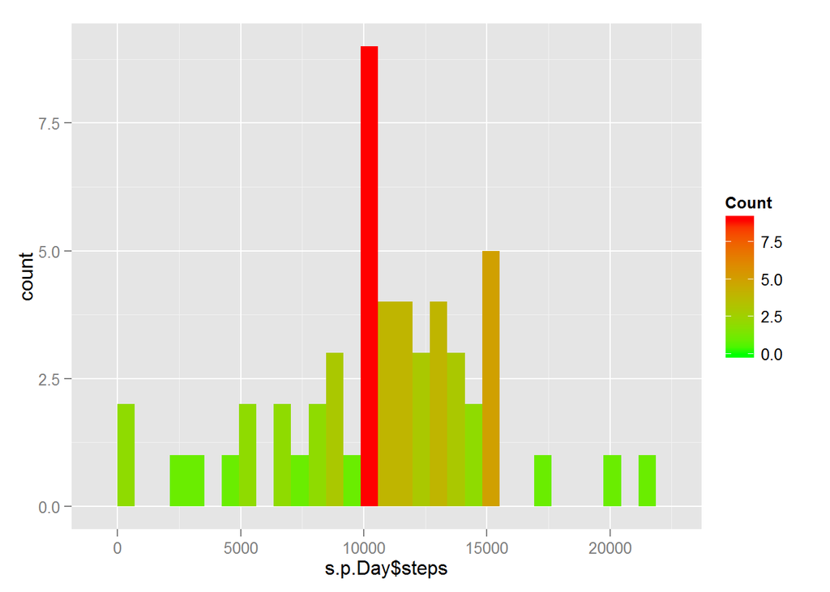

```r
library(ggplot2)
hist <- ggplot(s.p.Day,aes(x = s.p.Day$steps)) + geom_histogram(aes(fill=..count..))
hist + scale_fill_gradient("Count",low = "green",high = "red")
```

In addition to the histogram produced we will produce the mean and median of the aggregated data.

```r
MEAN <- mean(s.p.Day$steps)
MEDIAN <- median(s.p.Day$steps)
```

As a reult of the code we see that the average number of steps taken per day is approximately 10767 and the median number of steps taken per day is 10765.

## What is the average daily activity pattern?

Now we will look for the average daily activity pattern by observing the average number of steps taken over a 5 minute interval.

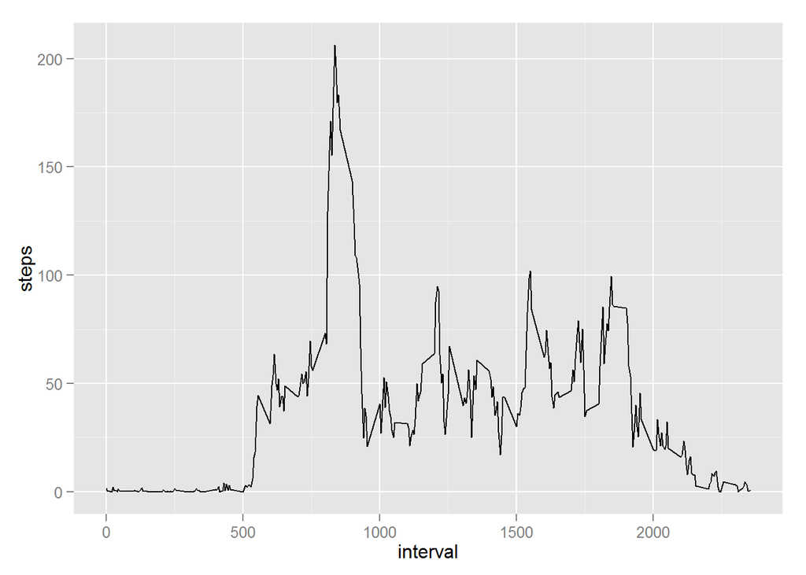

```r
s.p.Int <- aggregate(steps ~ interval, data = activity, FUN = mean)
time <- ggplot(s.p.Int, aes(x = interval, y = steps))
time + geom_line(stat = "identity")
```

From here we calculate to find the exact time where the maximum number of steps were taken,averaged across all days within the 5 min. interval

```r
s.p.Int$interval[which.max(s.p.Int$steps)]
```

```
## [1] 835
```

This result means that at 8:35 we have the maximum number of steps taken within the averaged 5 min. intervals across everyday.

## Imputing Missing Values

We look now for the total number of missing data from the original data set.

```r
length(which(is.na(activity)))
```

```
## [1] 2304
```

We will now fill in the missing data and create a new complete data set. To do this we compare the mean and median values to find which value would best represent the missing data.

```r
mean(na.omit(activity$steps))
```

```
## [1] 37.3826
```

```r
median(na.omit(activity$steps))
```

```
## [1] 0
```

As we can see, the mean produces 37.38 steps whereas the median produces 0 steps. Thus we shall use the mean as a representation of our missing data. Filling in the missing data we have:

```r
n.activity <- activity
n.activity$steps[is.na(n.activity$steps)] <- mean(na.omit(activity$steps))
```

Now we can view a completed dataset through the lens of a histogram as previously achieved without it.

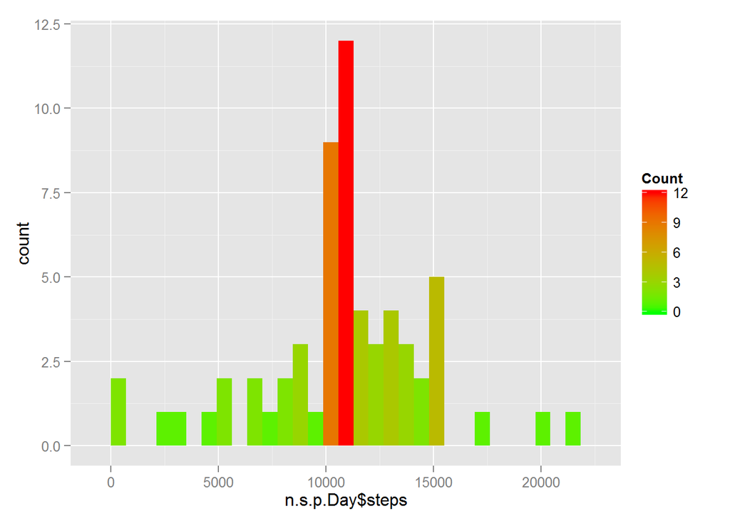

```r
n.s.p.Day <- aggregate(steps ~ date, data = n.activity, FUN = sum)
hist <- ggplot(n.s.p.Day,aes(x = n.s.p.Day$steps))
hist + geom_histogram(aes(fill=..count..)) +scale_fill_gradient("Count",low = "green",high = "red")
```

Calculating its corresponding mean and medians we have:

```r
N.MEAN <- mean(n.s.p.Day$steps)
N.MEDIAN <- median(n.s.p.Day$steps)
```

Finally we look at the impact of imputing the mising values from when they were omitted.

```r
MEAN - N.MEAN
```

```
## [1] 0
```

```r
MEDIAN - N.MEDIAN
```

```
## [1] -1.188679
```

## Are there differences in activity patterns between weekdays and weekends?

We first start off by creating the new factor variable.

```r
n.activity$day[weekdays(as.Date(n.activity$date)) %in% c("Saturday","sunday")] <-
  "weekend"
n.activity$day[!weekdays(as.Date(n.activity$date)) %in% c("Saturday","sunday")] <-
  "weekday"
n.activity$day <- as.factor(n.activity$day)
```

Now we shall create a panel time series plot to view weekdays and weekends on the 5 min. interval for the average no. of steps taken everyday.

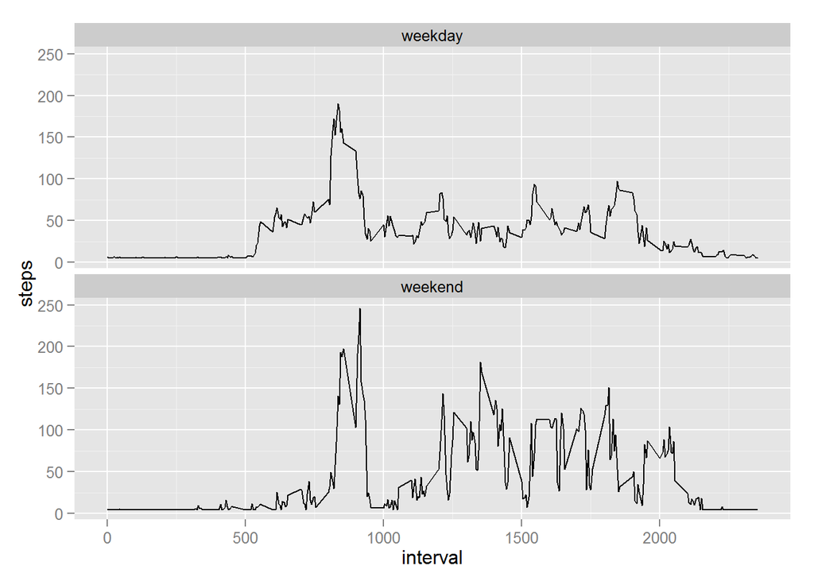

```r
n.s.p.Int <- aggregate(steps ~ interval + day, data = n.activity,FUN =mean)
n.time <- ggplot(n.s.p.Int,aes(x=interval,y=steps,group=1))
n.time + geom_line() + facet_wrap(~ day, ncol=1)
```